# CMPINF 2130 Summer 2022 - Midterm

Exploratory data analysis of video game data

Shirley Duong (auditing course)

Last Updated: 7/7/22

This document explores a **[video games dataset](https://github.com/rfordatascience/tidytuesday/tree/master/data/2019/2019-07-30)** from TidyTuesday.

# 1 Set up

Import libraries.

```r
library(tidyverse)
library(purrr)
library(lubridate)
```

Load data set.

```r
df <- read.csv("midterm_df2.csv")
```

# 2 Basic dataset info

Below is a glimpse of the video games dataset. There are 2590 rows/observations and 9 columns/variables.

```r
df %>% glimpse()
```

```
## Rows: 2,590
## Columns: 9
## $ game_name       <chr> "Neighbours from Hell Compilation", "Painkiller: Black…
## $ game_publisher  <chr> "THQ Nordic", "THQ Nordic", "THQ Nordic", "1C Entertai…
## $ game_metascore  <int> 69, NA, 83, 77, NA, 66, 63, NA, NA, 81, 77, 71, 35, NA…
## $ game_price      <dbl> 9.99, 9.99, 9.99, 4.99, 9.99, 4.99, 4.99, 6.99, 9.99, …
## $ game_free       <lgl> FALSE, FALSE, FALSE, FALSE, FALSE, FALSE, FALSE, FALSE…
## $ release_day     <int> 20, 12, 9, 29, 11, 24, 24, 2, 29, 16, 21, 29, 30, 25, …
## $ release_month   <int> 2, 4, 9, 6, 10, 8, 6, 6, 11, 6, 5, 11, 11, 6, 2, 2, 10…
## $ release_year    <int> 2004, 2004, 2004, 2004, 2004, 2004, 2004, 2004, 2004, …
## $ median_playtime <int> 0, 0, 0, 0, 0, 0, 0, 0, 0, 0, 0, 0, 0, 0, 0, 0, 0, 0, …
```

Below are the **variable descriptions**, taken directly from the midterm assignment instructions.

There are **7 categorical** variables:

- `game_name`: name of the video (nominal variable)
- `game_publisher`: publishing company for the game (nominal)
- `game_metascore`: ranking of the quality of the game (ordinal)
- `game_free`: whether the game free or not (TRUE or FALSE; nominal, binary)
- `release_day`: day in the month the game was released (ordinal)
- `release_month`: month in the year the game was released (ordinal)
- `release_year`: year the game was released (ordinal)

There are **2 continuous** variables:

- `game_price`: price of the game in US dollars
- `median_playtime`: median playtime for the game in minutes (this seems to be rounded to the nearest integer)

$~$

Below are the number of unique values per variable.

```r
df %>% map(., n_distinct)
```

```
## $game_name
## [1] 2578
##
## $game_publisher
## [1] 40
##
## $game_metascore
## [1] 57
##
## $game_price
## [1] 53
##
## $game_free
## [1] 1
##
## $release_day
## [1] 31
##
## $release_month
## [1] 12
##
## $release_year
## [1] 15
##
## $median_playtime
## [1] 92
```

It seems that across 40 game publishers, there are 2578 different games represented (`game_name`). I’m surprised that there are not 2590 games (the number of rows in the data set) represented. This might suggest that, if these data exist at the level of individual games (i.e., one row per game), then some game names are repeated or there is missing data for this variable.

Additionally, it seems like none of the games in the dataset were free, because there is only one unique value for `game_free` and it happens to be `FALSE` throughout the data set.

```r
df %>% map(., ~sum(is.na(.)))
```

```
## $game_name
## [1] 0
##
## $game_publisher
## [1] 0
##
## $game_metascore
## [1] 2038
##
## $game_price
## [1] 0
##
## $game_free
## [1] 0
##
## $release_day
## [1] 0
##
## $release_month
## [1] 0
##
## $release_year
## [1] 0
##
## $median_playtime
## [1] 1
```

It seems that there are no missing values for `game_name` so my next thought is that some names are repeated. Otherwise, why would there be less unique values than observations for this variable?

Also, another interesting observation is that a large proportion of the observations are missing `game_metascore` information.

I return to investigating `game_name` a bit more. Below, I try to show the duplicate values in `game_name`.

```r
df %>%
  select(game_name) %>%
  filter(duplicated(.))
```

```
##                                         game_name
## 1               Prince of Persia: The Two Thrones
## 2                  Tom Clancy's Rainbow Six Vegas
## 3               Brothers in Arms: Road to Hill 30
## 4               Brothers in Arms: Earned in Blood
## 5               Tom Clancy's Rainbow Six Lockdown
## 6         Tom Clancy's Splinter Cell Chaos Theory
## 7         Tom Clancy's Splinter Cell Double Agent
## 8              Dark Angels: Masquerade of Shadows
## 9                            Shtriga: Summer Camp
## 10                    The Esoterica: Hollow Earth
## 11                    The Saint: Abyss of Despair
## 12 Sacra Terra: Kiss of Death Collector’s Edition
```

Why is this happening? These don’t look like duplicates to me… I’ll think about this a bit more when I have time. Dr. Yurko, if you have any insight, please let me know, thanks!

# 3 Categorical variables

In this section, I explore counts of the categorical variables. I will ignore `game_name` because that is more like an identifier as well as `game_free` because there’s only one category represented here (none of the games were free!).

## 3.1 `game_metascore`

This variable is missing a lot of observations. Later, it might be interesting to look at which `game_publisher`s have the highest and lowest ranking games, but it would be hard to gauge whether this is meaningful with the large number of missing meta scores there are.

Meta scores range from 23 to 93.

```r
df %>% count(game_metascore) %>% head()
```

```
##   game_metascore n
## 1             23 1
## 2             35 2
## 3             38 2
## 4             39 1
## 5             41 2
## 6             43 2
```

```r
df %>% count(game_metascore) %>% tail()
```

```
##    game_metascore    n
## 52             89    4
## 53             90    3
## 54             91    1
## 55             92    3
## 56             93    2
## 57             NA 2038
```

Below, I plot a bar chart of the counts of meta scores, but there are too many categories, so I condense some of these rankings into bins. Also, I remove the missing observations so that their count doesn’t appear in the bar chart.

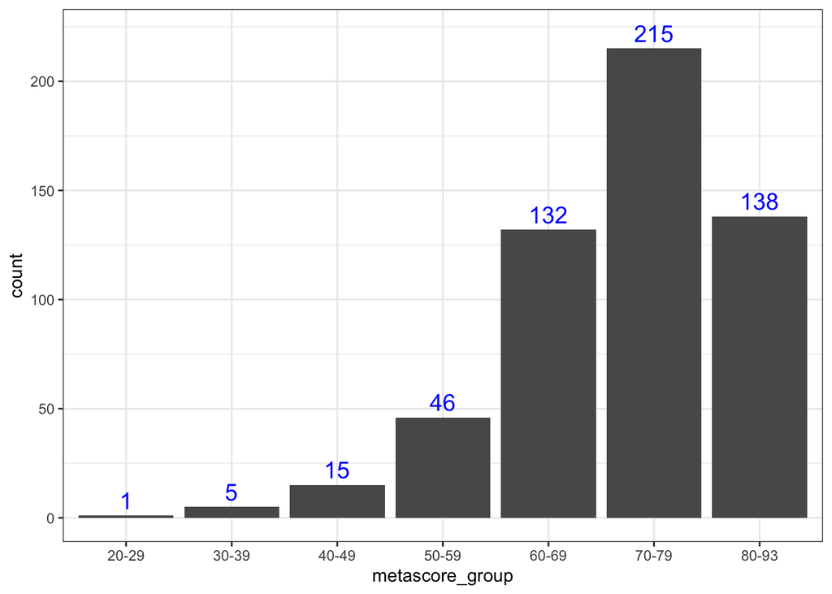

```r
df %>%
  select(game_metascore) %>%
  na.omit() %>%
  mutate(metascore_group = ifelse(game_metascore < 30, "20-29",
                                  ifelse(game_metascore >= 30 & game_metascore < 40, "30-39",
                                         ifelse(game_metascore >= 40 & game_metascore < 50, "40-49",
                                                ifelse(game_metascore >= 50 & game_metascore < 60, "50-59",
                                                       ifelse(game_metascore >= 60 & game_metascore < 70, "60-69",
                                                              ifelse(game_metascore >= 70 & game_metascore < 80, "70-79", "80-93"))))))) %>%
  ggplot(mapping = aes(x = metascore_group)) +
  geom_bar() +
  geom_text(stat = 'count',
            mapping = aes(label = stat(count)),
            size = 5, color = 'blue', nudge_y = 7) +
  theme_bw()
```

Assuming that these meta scores are on a 0 to 100 scale… it seems that most of these games are generally of “good” to “great” quality (i.e., with meta scores above 60).

## 3.2 `game_publisher`

There are a total of **40** game publishers in this data set. This is a lot of groups, I will plot the “top” publishers; these are associated with the most games in the data set. The rest of the publishers will be lumped into a single category.

```r
df %>% count(game_publisher)
```

```
##                           game_publisher   n
## 1                       1C Entertainment  84
## 2                            AGM PLAYISM  62
## 3                   Alawar Entertainment  46
## 4                          Artifex Mundi  65
## 5                             Atriagames  62
## 6                  Back To Basics Gaming  55
## 7             BANDAI NAMCO Entertainment  49
## 8                         Big Fish Games 141
## 9                     Buka Entertainment  55
## 10                       Choice of Games  92
## 11                Daedalic Entertainment  48
## 12                   Dagestan Technology  89
## 13                                Degica  78
## 14                      Devolver Digital  59
```

[output cut: 26 more lines]

Below, I plot a histogram of the counts of games that are represented across publishers. I am trying to figure out a good cut-off value to use for lumping publishers.

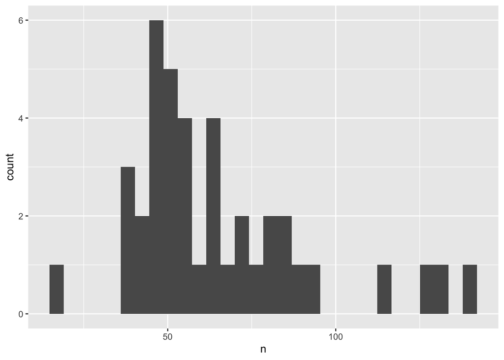

```r
df %>%
  count(game_publisher) %>%
  ggplot(mapping = aes(x = n)) +
  geom_histogram()
```

There is a peak around 50 games (per game publisher) and it looks like there are a few publishers with more than 100 games. I think 75 and 100 are a good cut-offs for lumping the publishers together.

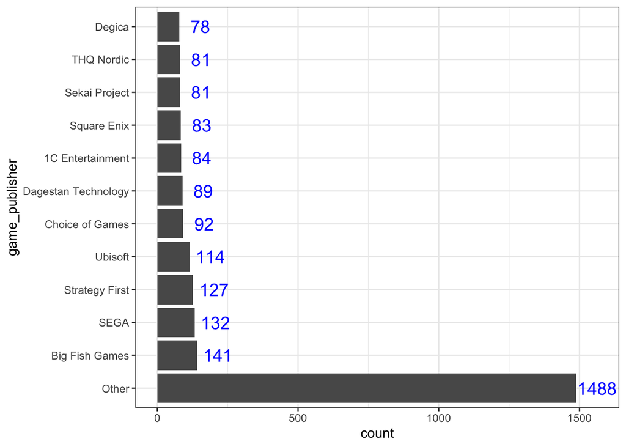

```r
df %>%
  mutate(game_publisher = forcats::fct_lump_min(game_publisher, 75)) %>%
  mutate(game_publisher = forcats::fct_infreq(game_publisher)) %>%
  ggplot(mapping = aes(y = game_publisher)) +
  geom_bar() +
  geom_text(stat = 'count',
            mapping = aes(label = stat(count)),
            size = 5, color = 'blue', nudge_x = 75) +
  theme_bw()
```

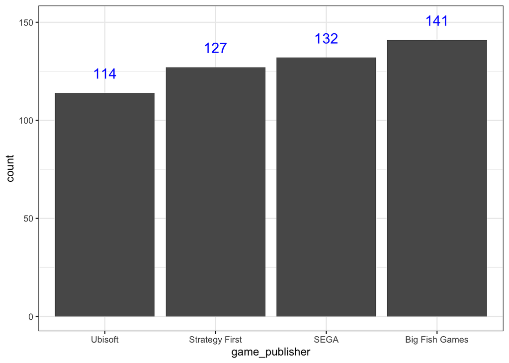

```r
df %>%
  mutate(game_publisher = forcats::fct_lump_min(game_publisher, 100)) %>%
  mutate(game_publisher = forcats::fct_rev(game_publisher)) %>%
  filter(game_publisher != "Other") %>%
  ggplot(mapping = aes(x = game_publisher)) +
  geom_bar() +
  geom_text(stat = 'count',
            mapping = aes(label = stat(count)),
            size = 5, color = 'blue', nudge_y = 10) +
  theme_bw()
```

The top 4 game publishers, based on the number of games represented in this data set and ordered by most to least games is Big Fish Games, SEGA, Strategy First, and Ubisoft. Those who play video games would not be surprised.

## 3.3 `release_day` and weekday

I don’t think it’s *that* interesting to see what *day* of the month the games were released. However, I do think that the **day of the week** would be interesting to look at so I explore that below.

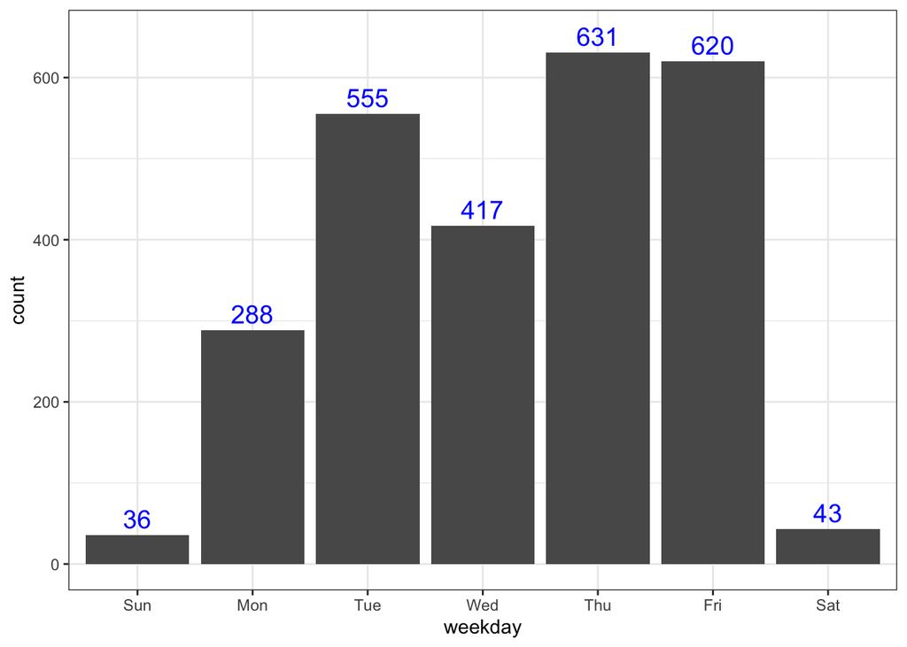

```r
df %>%
  #make weekday variable
  mutate(date = paste0(release_year, "-", release_month, "-", release_day),
         date = as.Date(date),
         weekday = wday(date,
                        label = TRUE)) %>%
  ggplot(mapping = aes(x = weekday)) +
  geom_bar() +
  geom_text(stat = 'count',
            mapping = aes(label = stat(count)),
            size = 5, color = 'blue', nudge_y = 20) +
  theme_bw()
```

It looks like most games are released on Thursdays, Fridays, and Tuesdays. My housemate just mentioned that releasing video games on Tuesday is an industry standard (but I don’t know when this started), so I wonder if Tuesday-released games are more frequent in more recent years, so even though there are bit more Thursday and Friday releases in this data set, these numbers may be driven by “older” release days. I’ll explore this later.

## 3.4 `release_month`

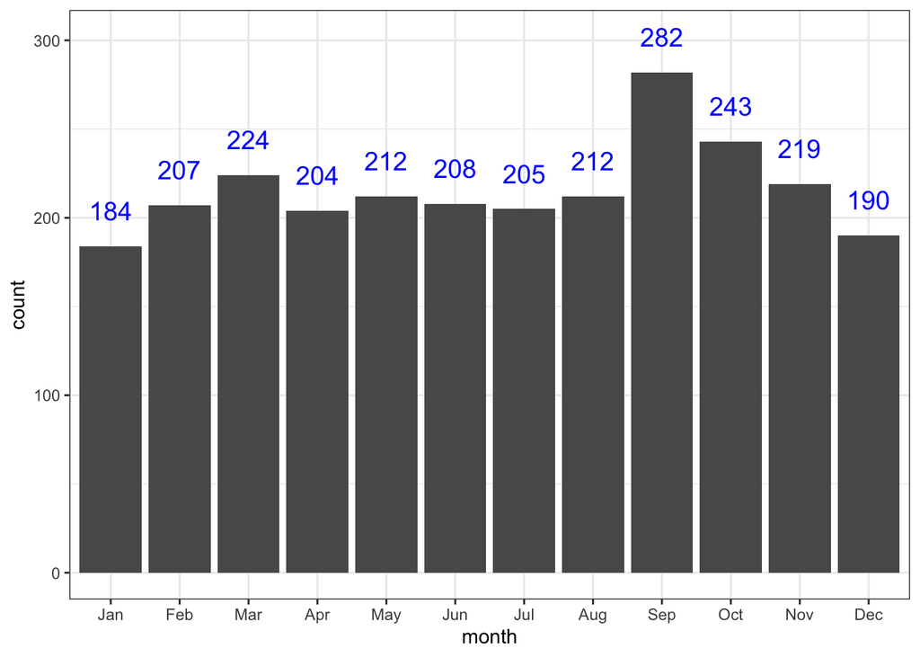

```r
df %>%
  mutate(date = paste0(release_year, "-", release_month, "-", release_day),
         date = as.Date(date),
         month = month(date,
                      label = TRUE)) %>%
  ggplot(mapping = aes(x = month)) +
  geom_bar() +
  geom_text(stat = 'count',
            mapping = aes(label = stat(count)),
            size = 5, color = 'blue', nudge_y = 20) +
  theme_bw()
```

Games are released pretty consistently throughout the year but there is a peak or jump right after the summer or at the start of the fall, i.e., month of September. I wonder why this is.

## 3.5 `release_year`

There are 15 dates represented from 2004 to 2018.

```r
df %>%
  mutate(date = paste0(release_year, "-", release_month, "-", release_day),
         date = as.Date(date),
         year = year(date)) %>%
  count(year)
```

```
##    year   n
## 1  2004  16
## 2  2005  20
## 3  2006  35
## 4  2007  41
## 5  2008  49
## 6  2009  53
## 7  2010 107
## 8  2011  84
## 9  2012  90
## 10 2013 110
## 11 2014 197
## 12 2015 284
## 13 2016 426
## 14 2017 545
## 15 2018 533
```

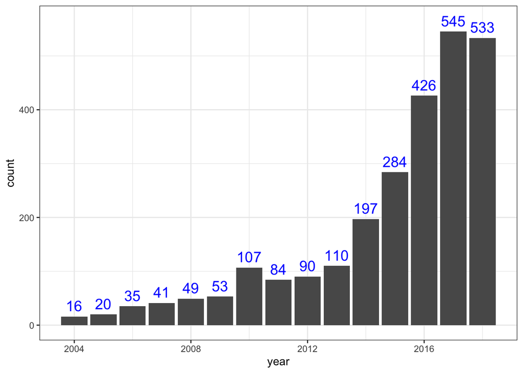

```r
df %>%
  mutate(date = paste0(release_year, "-", release_month, "-", release_day),
         date = as.Date(date),
         year = year(date)) %>%
  ggplot(mapping = aes(x = year)) +
  geom_bar() +
  geom_text(stat = 'count',
            mapping = aes(label = stat(count)),
            size = 5, color = 'blue', nudge_y = 20) +
  theme_bw()
```

Generally, more games are released as the years pass and the rate of release grows exponentially. There is a small bump in game releases in 2010 and after 2013, more and more games are released. The three years with the most games are 2016, 2017, and 2018.

# 4 Combos of categorical vars

## 4.1 `release_year` x weekday

Earlier in this document, I expressed an interest in looking at the day of the week that games were released and the release year to see if there’s a growing trend of releasing games on Tuesdays (again, I heard that this was an industry standard).

```r
df %>%
  mutate(date = paste0(release_year, "-", release_month, "-", release_day),
         date = as.Date(date),
         weekday = wday(date, label = TRUE),
         month = month(date, label = TRUE),
         year = year(date)) %>%
  mutate(year_group = cut(year, breaks = 6)) %>%
  count(weekday, year_group)
```

```
##    weekday  year_group   n
## 1      Sun (2004,2006]   3
## 2      Sun (2006,2009]   1
## 3      Sun (2009,2011]   5
## 4      Sun (2011,2013]   4
## 5      Sun (2013,2016]   3
## 6      Sun (2016,2018]  20
## 7      Mon (2004,2006]   8
## 8      Mon (2006,2009]   6
## 9      Mon (2009,2011]  29
## 10     Mon (2011,2013]  22
## 11     Mon (2013,2016]  48
## 12     Mon (2016,2018] 175
## 13     Tue (2004,2006]  19
## 14     Tue (2006,2009]  24
```

[output cut: 28 more lines]

Below, I plot a bar chart showing the number of games released per weekday by year. I examine the proportions instead of raw counts, sort of as a way to account for the fact that more games were released in later years overall.

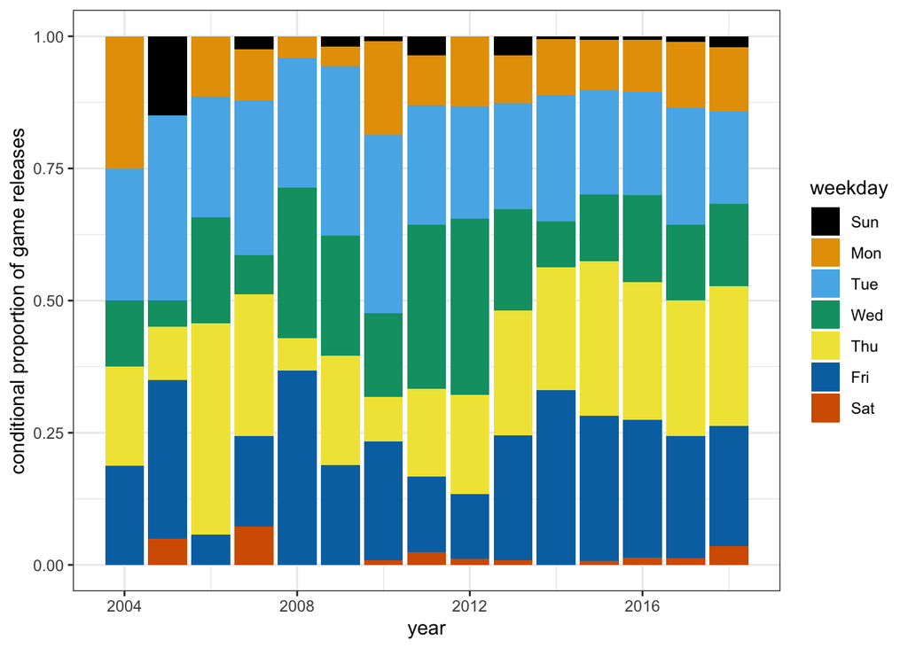

```r
df %>%
  mutate(date = paste0(release_year, "-", release_month, "-", release_day),
         date = as.Date(date),
         weekday = wday(date, label = TRUE),
         month = month(date, label = TRUE),
         year = year(date)) %>%
  mutate(year_group = cut(year, breaks = 6)) %>%
  ggplot(mapping = aes(x = year)) +
  geom_bar(mapping = aes(fill = as.factor(weekday)),
           position = 'fill') +
  ggthemes::scale_fill_colorblind('weekday') +
  labs(y = 'conditional proportion of game releases') +
  theme_bw()
```

It does **not** seem like more games get released on Tuesdays more often as the years pass. The proportion of games released on Tuesdays is relatively constant, especially from 2010 to 2018. However, the proportion of games released on Thursdays has grown since 2012 and the proportion of games released on Fridays has fluctuated a lot, relative to other weekdays.

## 4.2 `release_month` x `release_year`

In this section, I examine which months have the most games released across the years.

```r
df %>%
  mutate(date = paste0(release_year, "-", release_month, "-", release_day),
         date = as.Date(date),
         weekday = wday(date, label = TRUE),
         month = month(date, label = TRUE),
         year = year(date)) %>%
  count(release_month, release_year) %>%
  arrange(desc(n)) %>%
  head(n = 15)
```

```
##    release_month release_year  n
## 1              1         2018 64
## 2              2         2018 62
## 3              3         2018 62
## 4              9         2017 60
## 5              9         2018 59
## 6              8         2017 56
## 7             11         2017 53
## 8             10         2017 52
## 9             12         2017 49
## 10             5         2017 48
## 11             4         2018 46
## 12             9         2016 46
## 13             2         2017 45
## 14             6         2016 45
## 15             3         2017 44
```

If I look at all years and all months, and consider the raw counts of releases, it looks like the most games were released in 2018 or 2017 in the winter (Jan, Feb, Mar) or fall/winter months (Sept, Oct, Nov). However, more games were released overall in more recent years, so it would be helpful to look at proportions or split the plots up by year (e.g., facets might be easier to look at than grouped plots) and allow the y-axis scale to vary.

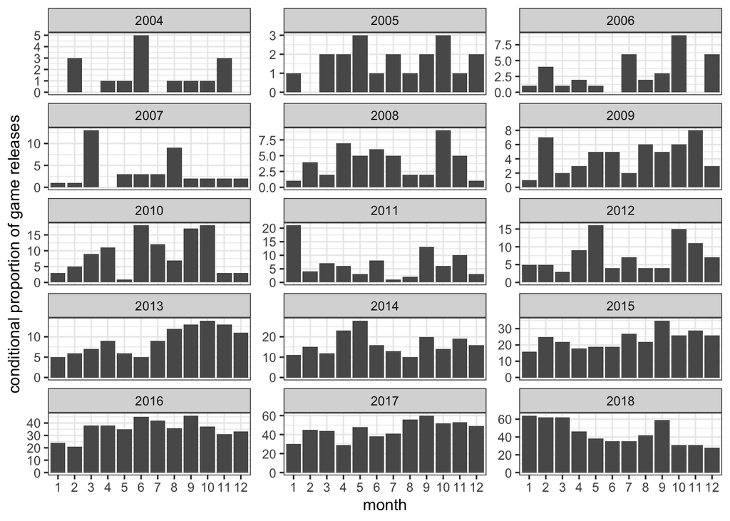

```r
df %>%
  mutate(date = paste0(release_year, "-", release_month, "-", release_day),
         date = as.Date(date),
         weekday = wday(date, label = TRUE),
         month = as.factor(month(date)),
         year = year(date)) %>%
  ggplot(mapping = aes(x = month)) +
  geom_bar() +
  facet_wrap(~year,
             ncol = 3,
             scales = "free_y") +
  labs(y = 'conditional proportion of game releases') +
  theme_bw()
```

Also, there seem to be more apparent “peaks” in video game releases in earlier years. In other words, it is easier to see these peaks or identify which months had more game releases in earlier years. For instance, in 2004 and 2007, when relatively less games were being made, publishers were obviously releasing most of their games during particular months (3 distinct months in 2004 and 2 in 2007). As more games were getting made, they were generally getting released throughout the year. We still see two peaks in almost every plot from 2012 and on, so it seems like publishers tend to release more games during certain months, but those peaks are less “sharp”. I’m not sure if “sharp” is the right word, but I guess I’m trying to say that the release of games during particular months becomes less prominent as time goes on (I’m so bad with words… I don’t know if “prominent” is right either, but I think you get what I mean!).

# 5 Continuous variables

## 5.1 `game_price`

Below is a histogram overlayed with a density plot of the distribution of game prices in US dollars.

```
## size aesthetic has been deprecated for use with lines as of ggplot2 3.4.0
## ℹ Please use linewidth aesthetic instead
```

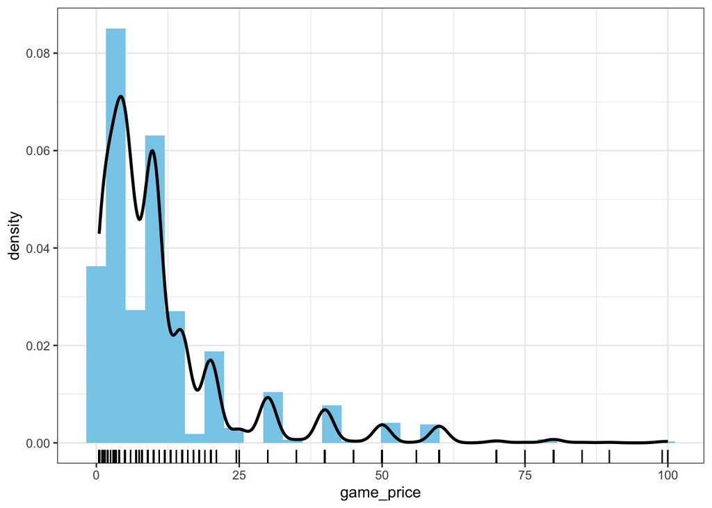

```r
df %>%
  ggplot(mapping = aes(x = game_price)) +
  geom_histogram(bins = 30,
                 fill = 'skyblue',
                 mapping = aes(y = stat(density))) +
  geom_density(size = 1, color = 'black') +
  geom_rug() +
  theme_bw()
```

Overall, it seems that games are mostly under 25 dollars. The part of the plot that shows values around 0 dollars is a bit misleading because no games were free. The cheapest game was $0.49! Additionally, there are two peaks for game prices under 25 dollars. Below, I explore this section of the plot.

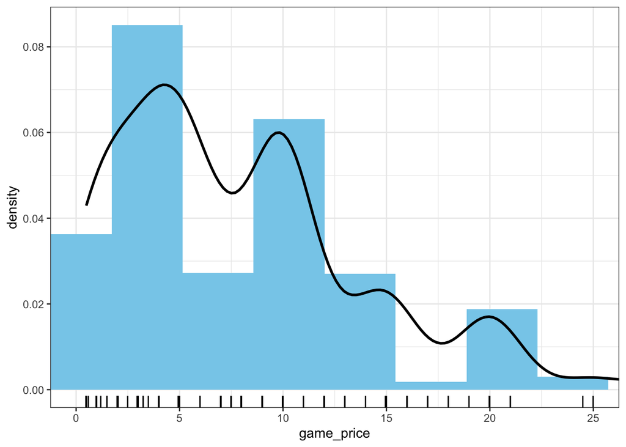

```r
df %>%
  ggplot(mapping = aes(x = game_price)) +
  geom_histogram(bins = 30,
                 fill = 'skyblue',
                 mapping = aes(y = stat(density))) +
  geom_density(size = 1, color = 'black') +
  geom_rug() +
  coord_cartesian(xlim = c(0,25)) +
  theme_bw()
```

Many games are around 5 or 10 dollars. Below, I show some summary statistics of this variable, including the min, max, mean, and quantiles.

```r
df %>% select(game_price) %>%
  summary()
```

```
##    game_price
##  Min.   : 0.49
##  1st Qu.: 3.99
##  Median : 7.99
##  Mean   :11.41
##  3rd Qu.:14.99
##  Max.   :99.99
```

## 5.2 `median_playtime`

Below, I plot the distribution of `median_playtime` and show some summary statistics of this variable, including the min, max, mean, and quantiles.

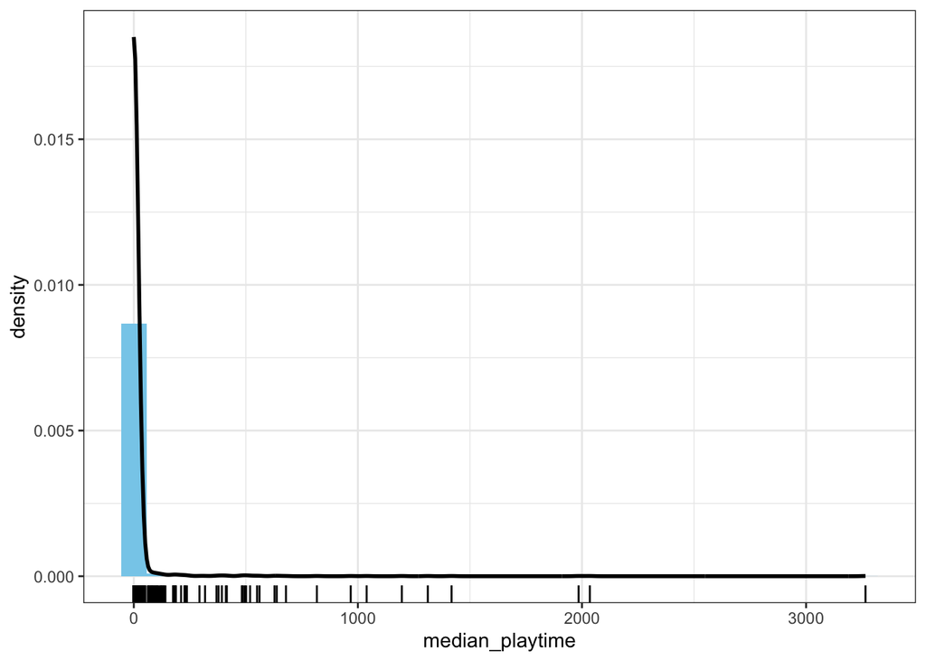

```r
df %>%
  select(median_playtime) %>%
  na.omit() %>%
  ggplot(mapping = aes(x = median_playtime)) +
  geom_histogram(bins = 30,
                 fill = 'skyblue',
                 mapping = aes(y = stat(density))) +
  geom_density(size = 1, color = 'black') +
  geom_rug() +
  theme_bw()
```

There’s at least one very extreme value of minutes of playtime!

```r
df %>% select(median_playtime) %>%
  summary()
```

```
##  median_playtime
##  Min.   :   0.00
##  1st Qu.:   0.00
##  Median :   0.00
##  Mean   :  10.83
##  3rd Qu.:   0.00
##  Max.   :3265.00
##  NA's   :1
```

There’s a max value of 3,265 minutes as the MEDIAN play time. We cannot tell from this dataset how many observations were collected to calculate this median (or any of the medians). I want to take a look at this distribution without this value.

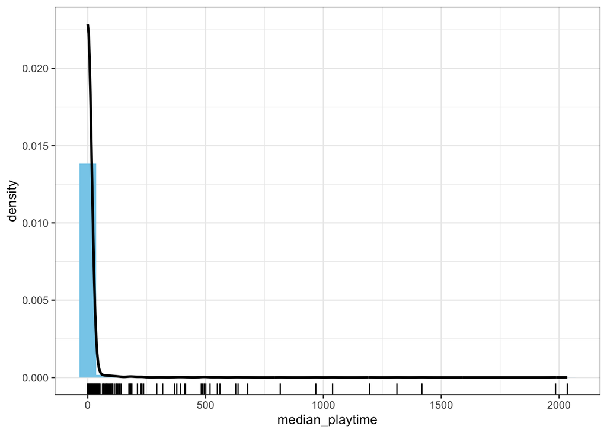

```r
df %>%
  select(median_playtime) %>%
  na.omit() %>%
  filter(median_playtime < 3265) %>%
  ggplot(mapping = aes(x = median_playtime)) +
  geom_histogram(bins = 30,
                 fill = 'skyblue',
                 mapping = aes(y = stat(density))) +
  geom_density(size = 1, color = 'black') +
  geom_rug() +
  theme_bw()
```

That didn’t really help. I see that most of the median play times are less than 100 minutes, so I will filter based on this number.

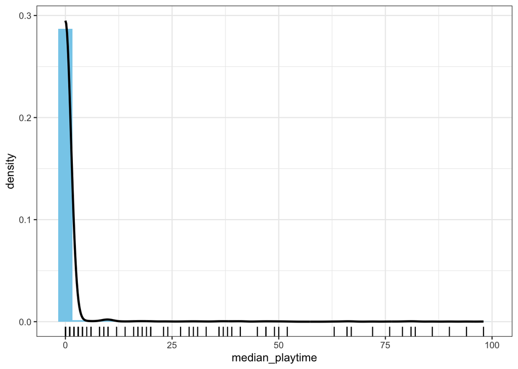

```r
df %>%
  select(median_playtime) %>%
  na.omit() %>%
  filter(median_playtime < 100) %>%
  ggplot(mapping = aes(x = median_playtime)) +
  geom_histogram(bins = 30,
                 fill = 'skyblue',
                 mapping = aes(y = stat(density))) +
  geom_density(size = 1, color = 'black') +
  geom_rug() +
  theme_bw()
```

That didn’t do much either so I’m guessing that the median play time is mostly 0 minutes in this data set.

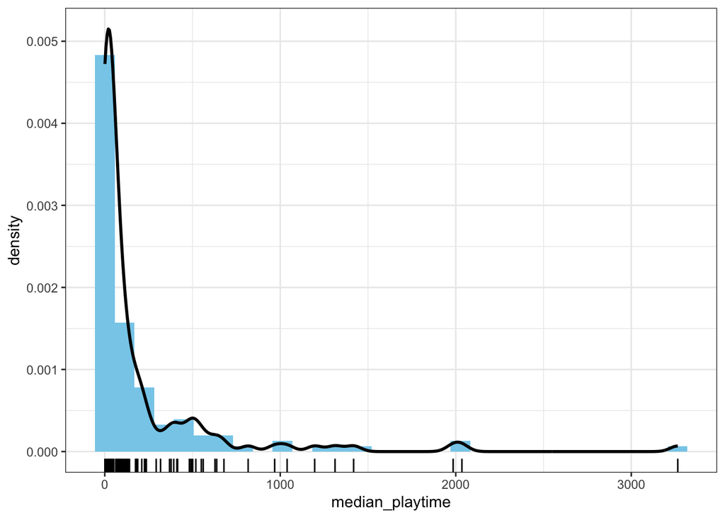

```r
df %>%
  select(median_playtime) %>%
  na.omit() %>%
  filter(median_playtime > 0) %>%
  ggplot(mapping = aes(x = median_playtime)) +
  geom_histogram(bins = 30,
                 fill = 'skyblue',
                 mapping = aes(y = stat(density))) +
  geom_density(size = 1, color = 'black') +
  geom_rug() +
  theme_bw()
```

Here, if I remove median play times equal to 0 minutes, we see that a good chunk of the data set has median play times above 0, but the median play times are still relatively low in minutes, i.e., they are really close to 0.

## 5.3 `game_price` x `median_playtime`

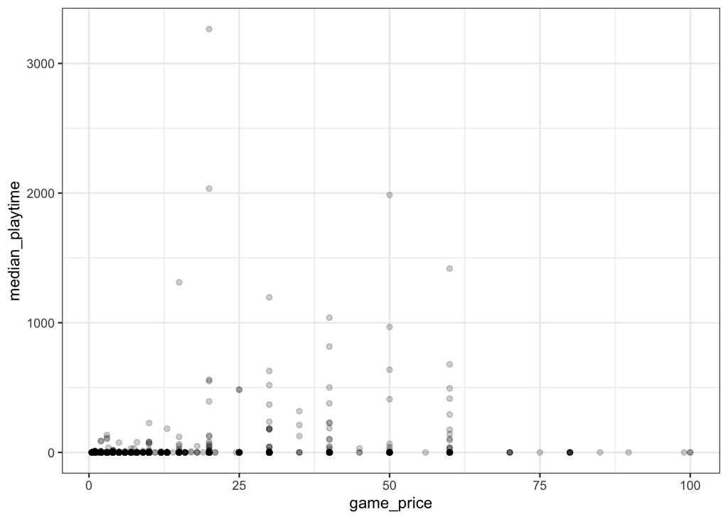

```r
df %>%
  ggplot(mapping = aes(x = game_price, y = median_playtime)) +
  geom_point(alpha = .2) +
  theme_bw()
```

# 6 Combos of cont x cat vars

## 6.1 `game_price` x `game_publisher`

Below, game prices by publisher are examined. There are 40 game publishers. That’s a lot so I’m just going to look at the top 4 in terms of games released and lump all other publishers into one group.

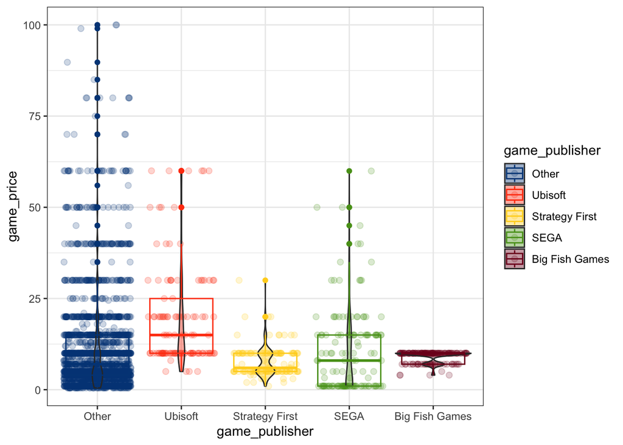

```r
df %>%
  mutate(game_publisher = forcats::fct_lump_min(game_publisher, 100)) %>%
  mutate(game_publisher = forcats::fct_rev(game_publisher)) %>%
  ggplot(mapping = aes(x = game_publisher, y = game_price)) +
  geom_jitter(alpha = .2,
              size = 2,
              mapping = aes(color = game_publisher)) +
  geom_violin(alpha = .4,
              mapping = aes(fill = game_publisher)) +
  geom_boxplot(fill = NA,
               mapping = aes(color = game_publisher)) +
  ggthemes::scale_color_calc() +
  ggthemes::scale_fill_calc() +
  theme_bw()
```

“Big name” video game publishers weren’t making a lot of lowly priced games. With the exception of SEGA, the other top publishers did **NOT** make any games that were less than 1 dollar. On the flip side, publishers in the “Other” group, which comprises of companies who produced less games relative to these top four, were producing games that were very cheap.

Next, the distributions of `game_price` by `game_publisher` are examined for games with median play times above 0 minutes.

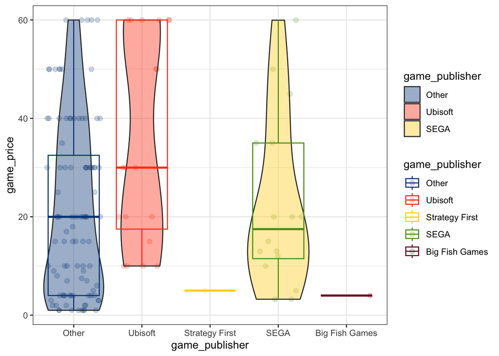

```r
df %>%
  mutate(game_publisher = forcats::fct_lump_min(game_publisher, 100)) %>%
  mutate(game_publisher = forcats::fct_rev(game_publisher)) %>%
  filter(median_playtime > 0) %>%
  ggplot(mapping = aes(x = game_publisher, y = game_price)) +
  geom_jitter(alpha = .2,
              size = 2,
              mapping = aes(color = game_publisher)) +
  geom_violin(alpha = .4,
              mapping = aes(fill = game_publisher)) +
  geom_boxplot(fill = NA,
               mapping = aes(color = game_publisher)) +
  ggthemes::scale_color_calc() +
  ggthemes::scale_fill_calc() +
  theme_bw()
```

## 6.2 `game_publisher` x `median_playtime`

Below, median play time by publisher are examined.

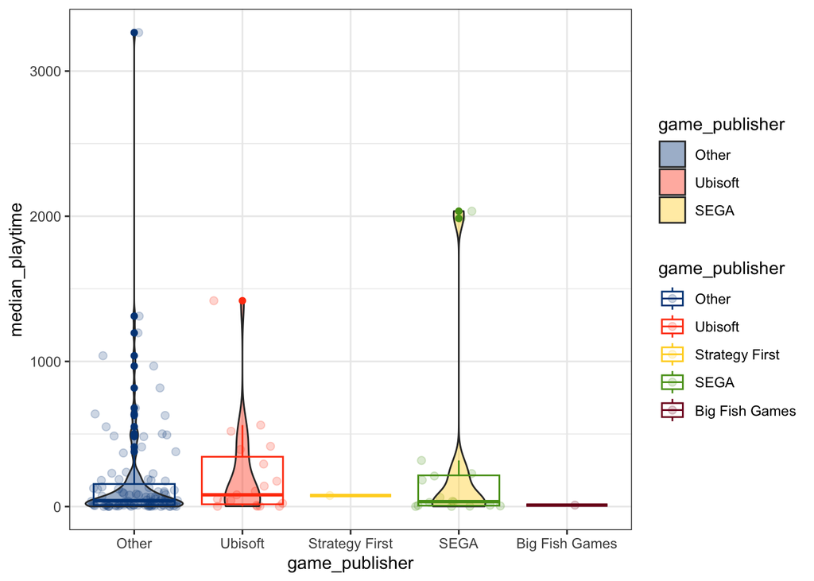

```r
df %>%
  mutate(game_publisher = forcats::fct_lump_min(game_publisher, 100)) %>%
  mutate(game_publisher = forcats::fct_rev(game_publisher)) %>%
  filter(median_playtime > 0) %>%
  ggplot(mapping = aes(x = game_publisher, y = median_playtime)) +
  geom_jitter(alpha = .2,
              size = 2,
              mapping = aes(color = game_publisher)) +
  geom_violin(alpha = .4,
              mapping = aes(fill = game_publisher)) +
  geom_boxplot(fill = NA,
               mapping = aes(color = game_publisher)) +
  ggthemes::scale_color_calc() +
  ggthemes::scale_fill_calc() +
  theme_bw()
```

Again, we have taken out games with median play times of 0 minutes, so Strategy First and Big Fish Games do not have distributions. For the other three categories of publishers, the distributions of play times are skewed to the “left” or “bottom” which suggests that play times for many of these games are relatively short. However, as we saw earlier, there were some extreme game times. The plot above is resized to examine the distributions.

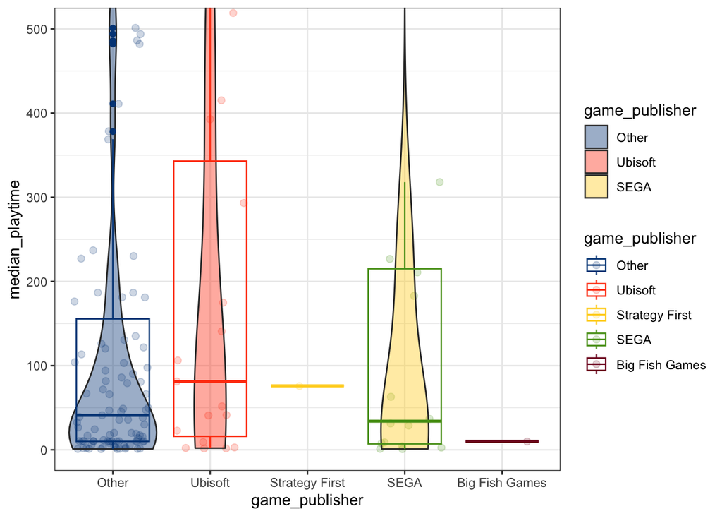

```r
df %>%
  mutate(game_publisher = forcats::fct_lump_min(game_publisher, 100)) %>%
  mutate(game_publisher = forcats::fct_rev(game_publisher)) %>%
  filter(median_playtime > 0) %>%
  ggplot(mapping = aes(x = game_publisher, y = median_playtime)) +
  geom_jitter(alpha = .2,
              size = 2,
              mapping = aes(color = game_publisher)) +
  geom_violin(alpha = .4,
              mapping = aes(fill = game_publisher)) +
  geom_boxplot(fill = NA,
               mapping = aes(color = game_publisher)) +
  coord_cartesian(ylim = c(0, 500)) +
  ggthemes::scale_color_calc() +
  ggthemes::scale_fill_calc() +
  theme_bw()
```

Now, it’s easier to see that, for games with median play times above 0 minutes, Ubisoft has games with the greatest average median play time, followed by publishers in the “Other” category and then SEGA.

On average, Ubisoft has the greatest game price and median play time. I’m wondering if, within the top 4 publishers’ and Ubisoft’s games, and for play times above 0, there is a relation between game prices and median play times.

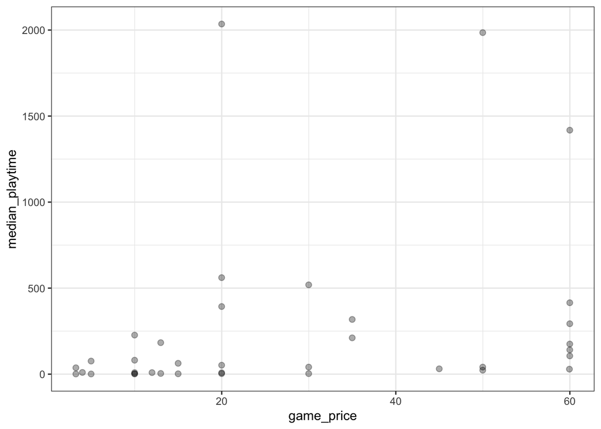

```r
df %>%
  filter(game_publisher %in% c("Ubisoft", "SEGA", "Big Fish Games", "Strategy First")) %>%
  filter(median_playtime > 0) %>%
  ggplot(mapping = aes(x = game_price, y = median_playtime)) +
  geom_point(alpha = .33, size = 2) +
  theme_bw()
```

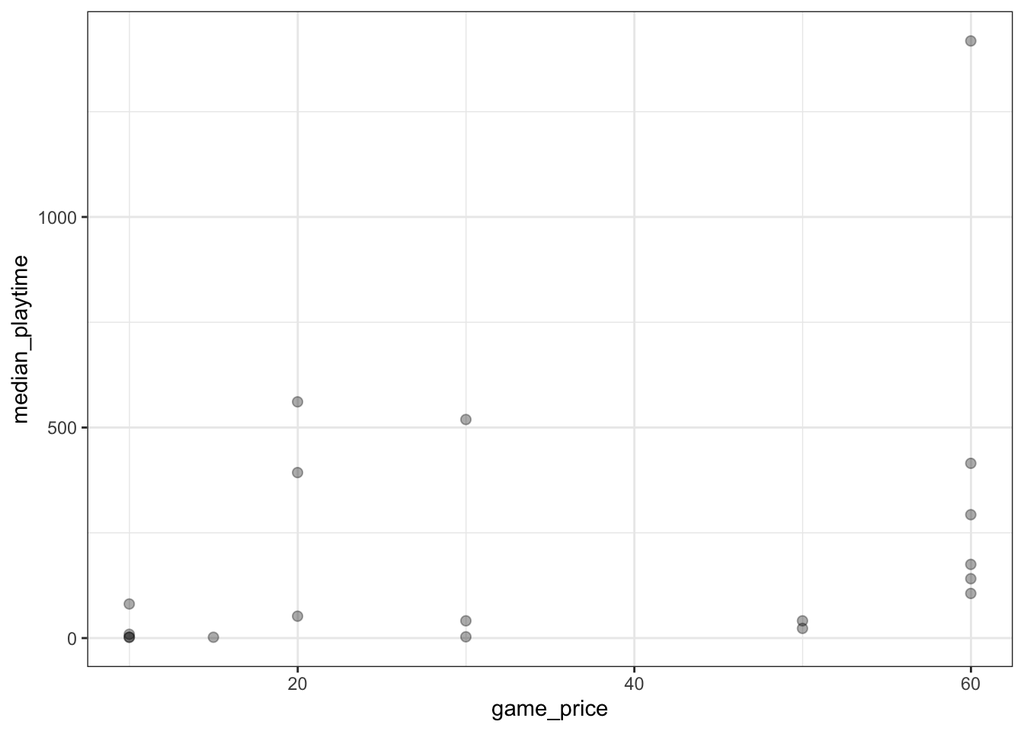

```r
df %>%
  filter(game_publisher == "Ubisoft") %>%
  filter(median_playtime > 0) %>%
  ggplot(mapping = aes(x = game_price, y = median_playtime)) +
  geom_point(alpha = .33, size = 2) +
  theme_bw()
```

It doesn’t look like there is a relation between game price and median play times in either of these scenarios. It is the case that some more expensive games have higher play times, but overall, all game prices are associated with really low median play times (around 0 minutes).